Wine Quality by Naseer Faheem

```
##   X fixed.acidity volatile.acidity citric.acid residual.sugar chlorides
## 1 1           7.4             0.70        0.00            1.9     0.076
## 2 2           7.8             0.88        0.00            2.6     0.098
## 3 3           7.8             0.76        0.04            2.3     0.092
## 4 4          11.2             0.28        0.56            1.9     0.075
## 5 5           7.4             0.70        0.00            1.9     0.076
## 6 6           7.4             0.66        0.00            1.8     0.075
##   free.sulfur.dioxide total.sulfur.dioxide density   pH sulphates alcohol
## 1                  11                   34  0.9978 3.51      0.56     9.4
## 2                  25                   67  0.9968 3.20      0.68     9.8
## 3                  15                   54  0.9970 3.26      0.65     9.8
## 4                  17                   60  0.9980 3.16      0.58     9.8
## 5                  11                   34  0.9978 3.51      0.56     9.4
## 6                  13                   40  0.9978 3.51      0.56     9.4
##   quality type
## 1       5  red
## 2       5  red
## 3       5  red
## 4       6  red
## 5       5  red
## 6       5  red
```

```
##         X fixed.acidity volatile.acidity citric.acid residual.sugar
## 6492 4893           6.5             0.23        0.38            1.3
## 6493 4894           6.2             0.21        0.29            1.6
## 6494 4895           6.6             0.32        0.36            8.0
## 6495 4896           6.5             0.24        0.19            1.2
## 6496 4897           5.5             0.29        0.30            1.1
## 6497 4898           6.0             0.21        0.38            0.8
##      chlorides free.sulfur.dioxide total.sulfur.dioxide density   pH
## 6492     0.032                  29                  112 0.99298 3.29
## 6493     0.039                  24                   92 0.99114 3.27
## 6494     0.047                  57                  168 0.99490 3.15
## 6495     0.041                  30                  111 0.99254 2.99
## 6496     0.022                  20                  110 0.98869 3.34
## 6497     0.020                  22                   98 0.98941 3.26
##      sulphates alcohol quality  type
## 6492      0.54     9.7       5 white
## 6493      0.50    11.2       6 white
## 6494      0.46     9.6       5 white
## 6495      0.46     9.4       6 white
## 6496      0.38    12.8       7 white
## 6497      0.32    11.8       6 white
```

# Introduction:

Before going furthur in the analysis, its import to know the variables in the dataset and what they represent. The following two sections describe each variable in great detail so that it makes it easier to understand the result of the dataset.

## Attribute information:

For more information, read [Cortez et al., 2009]. Input variables (based on physicochemical tests)

1 - fixed acidity (tartaric acid - g / dm^3)  
2 - volatile acidity (acetic acid - g / dm^3)  
3 - citric acid (g / dm^3)  
4 - residual sugar (g / dm^3)  
5 - chlorides (sodium chloride - g / dm^3  
6 - free sulfur dioxide (mg / dm^3)  
7 - total sulfur dioxide (mg / dm^3)  
8 - density (g / cm^3)  
9 - pH  
10 - sulphates (potassium sulphate - g / dm3)  
11 - alcohol (% by volume)  
Output variable (based on sensory data):  
12 - quality (score between 0 and 10)

## Description of attributes:

1 - fixed acidity: most acids involved with wine or fixed or nonvolatile (do not evaporate readily)  
2 - volatile acidity: the amount of acetic acid in wine, which at too high of levels can lead to an unpleasant, vinegar taste  
3 - citric acid: found in small quantities, citric acid can add ‘freshness’ and flavor to wines  
4 - residual sugar: the amount of sugar remaining after fermentation stops, it’s rare to find wines with less than 1 gram/liter and wines with greater than 45 grams/liter are considered sweet  
5 - chlorides: the amount of salt in the wine  
6 - free sulfur dioxide: the free form of SO2 exists in equilibrium between molecular SO2 (as a dissolved gas) and bisulfite ion; it prevents microbial growth and the oxidation of wine  
7 - total sulfur dioxide: amount of free and bound forms of S02; in low concentrations, SO2 is mostly undetectable in wine, but at free SO2 concentrations over 50 ppm, SO2 becomes evident in the nose and taste of wine  
8 - density: the density of water is close to that of water depending on the percent alcohol and sugar content  
9 - pH: describes how acidic or basic a wine is on a scale from 0 (very acidic) to 14 (very basic); most wines are between 3-4 on the pH scale  
10 - sulphates: a wine additive which can contribute to sulfur dioxide gas (S02) levels, wich acts as an antimicrobial and antioxidant  
11 - alcohol: the percent alcohol content of the wine

Output variable (based on sensory data):  
12 - quality (score between 0 and 10)

# Univariate Plots Section

```
##        X        fixed.acidity    volatile.acidity  citric.acid
##  Min.   :   1   Min.   : 3.800   Min.   :0.0800   Min.   :0.0000
##  1st Qu.: 813   1st Qu.: 6.400   1st Qu.:0.2300   1st Qu.:0.2500
##  Median :1650   Median : 7.000   Median :0.2900   Median :0.3100
##  Mean   :2044   Mean   : 7.215   Mean   :0.3397   Mean   :0.3186
##  3rd Qu.:3274   3rd Qu.: 7.700   3rd Qu.:0.4000   3rd Qu.:0.3900
##  Max.   :4898   Max.   :15.900   Max.   :1.5800   Max.   :1.6600
##  residual.sugar     chlorides       free.sulfur.dioxide
##  Min.   : 0.600   Min.   :0.00900   Min.   :  1.00
##  1st Qu.: 1.800   1st Qu.:0.03800   1st Qu.: 17.00
##  Median : 3.000   Median :0.04700   Median : 29.00
##  Mean   : 5.443   Mean   :0.05603   Mean   : 30.53
##  3rd Qu.: 8.100   3rd Qu.:0.06500   3rd Qu.: 41.00
##  Max.   :65.800   Max.   :0.61100   Max.   :289.00
##  total.sulfur.dioxide    density             pH          sulphates
##  Min.   :  6.0        Min.   :0.9871   Min.   :2.720   Min.   :0.2200
##  1st Qu.: 77.0        1st Qu.:0.9923   1st Qu.:3.110   1st Qu.:0.4300
##  Median :118.0        Median :0.9949   Median :3.210   Median :0.5100
##  Mean   :115.7        Mean   :0.9947   Mean   :3.219   Mean   :0.5313
##  3rd Qu.:156.0        3rd Qu.:0.9970   3rd Qu.:3.320   3rd Qu.:0.6000
##  Max.   :440.0        Max.   :1.0390   Max.   :4.010   Max.   :2.0000
##     alcohol         quality          type
##  Min.   : 8.00   Min.   :3.000   Length:6497
##  1st Qu.: 9.50   1st Qu.:5.000   Class :character
##  Median :10.30   Median :6.000   Mode  :character
##  Mean   :10.49   Mean   :5.818
##  3rd Qu.:11.30   3rd Qu.:6.000
##  Max.   :14.90   Max.   :9.000
```

# Plotting:

# 1. Univariate Plotting:

In this section, I will be plotting the distribution of the individual variable of the dataset to get a thourgh understanding. It will also help us see where the the majority of the observations are for each variable. After plotting all the variables individually, I will pick a few.

## 1.1.1 Fixed Acidity:

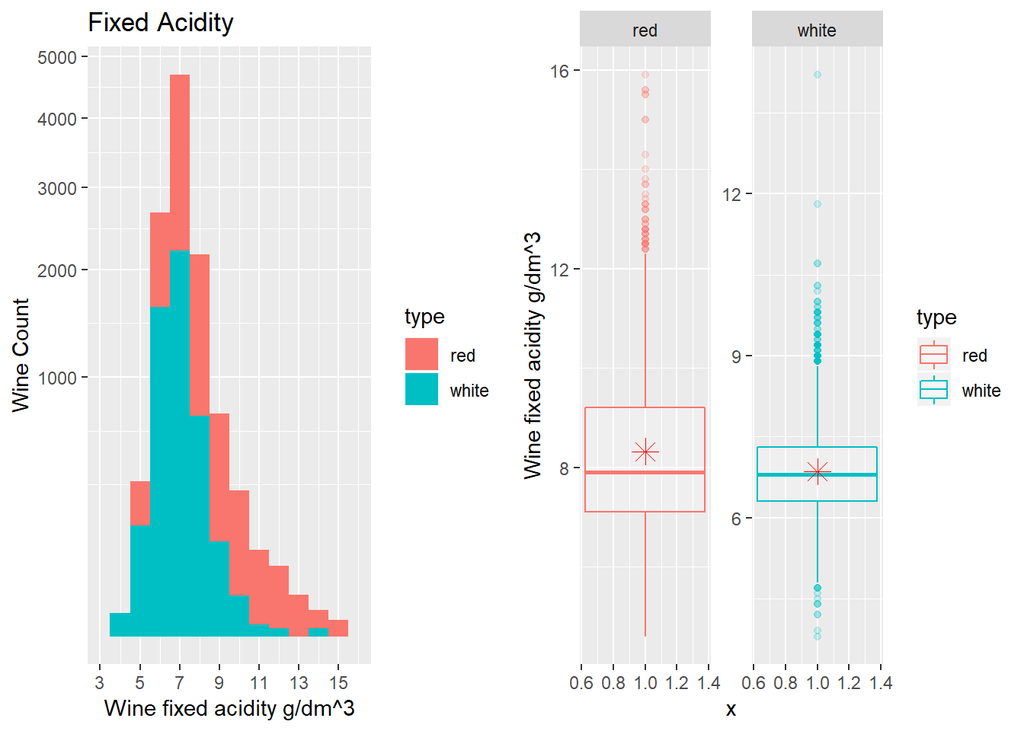

```
## # A tibble: 2 x 4
##   type   mean median     n
##   <chr> <dbl>  <dbl> <int>
## 1 red    8.32    7.9  1599
## 2 white  6.85    6.8  4898
```

## 1.2.1 Volatile Acidity:

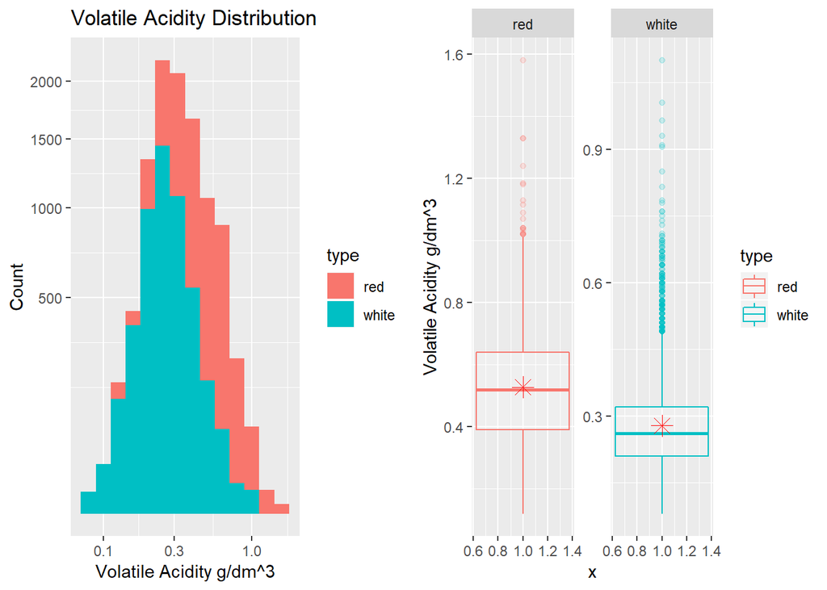

```
## # A tibble: 2 x 4
##   type   mean median     n
##   <chr> <dbl>  <dbl> <int>
## 1 red   0.528   0.52  1599
## 2 white 0.278   0.26  4898
```

1.2.2 Volatile acidity has almost a similar distribution for both wine types. It seems that red wine has a little higher volatile acitidy (0.53) whereas white volatile acidity level is low (0.28), which makes sense becuase a wine with too more acetic acid could lead to an unpleaseant vinegar taste. The interesting observation here is the majority of white wine observations have volatile acidity of lower than 0.3 g/dm^3 whereas the majority of red wines have higher than 0.4 g/dm^3.

## 1.3.1 Citric Acid:

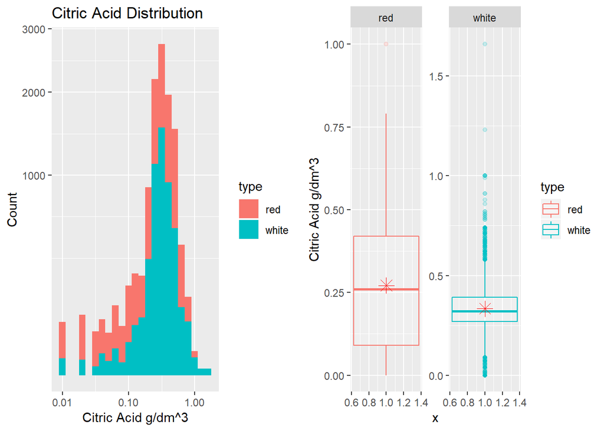

```
## # A tibble: 2 x 4
##   type   mean median     n
##   <chr> <dbl>  <dbl> <int>
## 1 red   0.271   0.26  1599
## 2 white 0.334   0.32  4898
```

1.3.2 Both wines appear to have normal distribution for Citric Acid levels, which is below 1. However, there are a few outliers for white wine which has a citric acid level of higher than 1.0. Red wine seems to have only few outliers as we can see in the boxplots.

## 1.4.1 Residual Sugar:

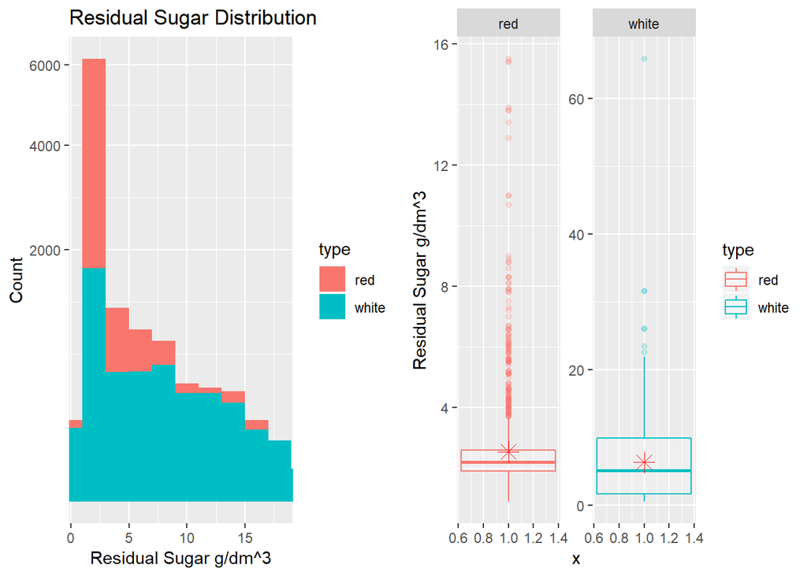

```
## # A tibble: 2 x 4
##   type   mean median     n
##   <chr> <dbl>  <dbl> <int>
## 1 red    2.54    2.2  1599
## 2 white  6.39    5.2  4898
```

1.4.2 Both wine are have skewed distributions. Here, the white wine appears to have one outlier which has a residual sugar level of 66 grams/liter. It is pretty rare to find a wine with that much sugar in it. In general it looks like white wines have higher sugar contents despite having an outlier. I base my assumption on the median of the white wine. I choose to remove the outliers in the histogram, however, we could still those outliers in the boxplots.

## 1.5.1 Chlorides:

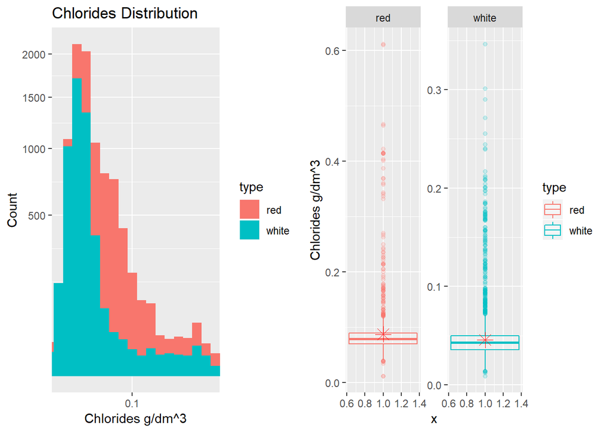

```
## # A tibble: 2 x 4
##   type    mean median     n
##   <chr>  <dbl>  <dbl> <int>
## 1 red   0.0875  0.079  1599
## 2 white 0.0458  0.043  4898
```

1.5.2 As we can see in both the plot and the summary table that red wines have higher levels of chlorides. It makes sense since we noticed earlier that white wine has higher residual sugar level. The box plots hows the exact distribution of chlorides in the wines. The majority of wines have chlorides lower than 0.1 g /dm^3.

## 1.6.1 Free Sulfur Dioxide:

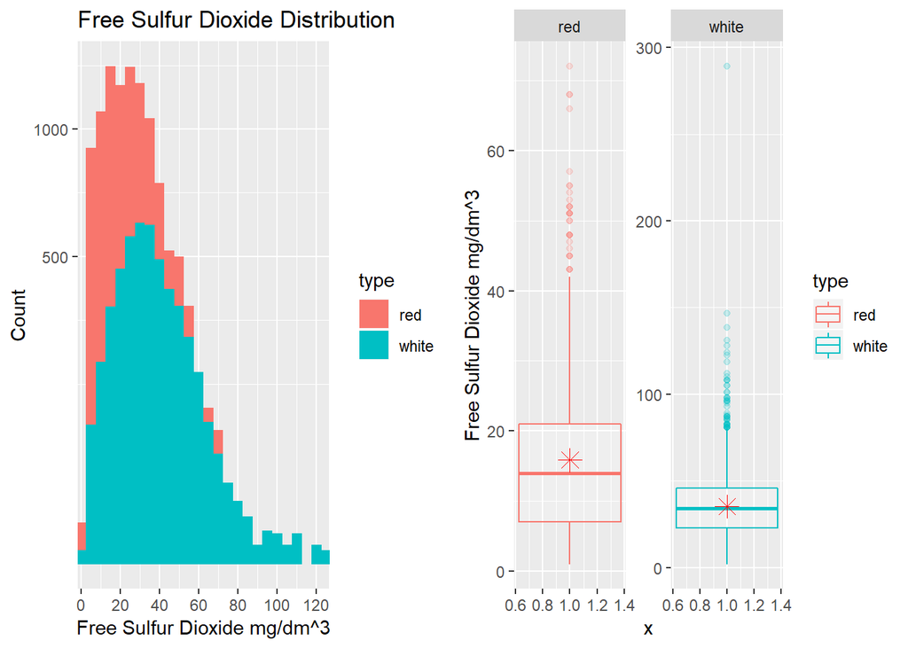

```
## # A tibble: 2 x 4
##   type   mean median     n
##   <chr> <dbl>  <dbl> <int>
## 1 red    15.9     14  1599
## 2 white  35.3     34  4898
```

1.6.2 The white wine has on average about 20 mg more free sulfur dioxide than the red wine. It will be interesting to see the relationship of free sulfur dioxide and chloride and sugar for each type of wine. As we can see, the white wine has an outlier where the free sulfur dioxide level is up to 300.

## 1.7.1 Total Sulfur Dioxide:

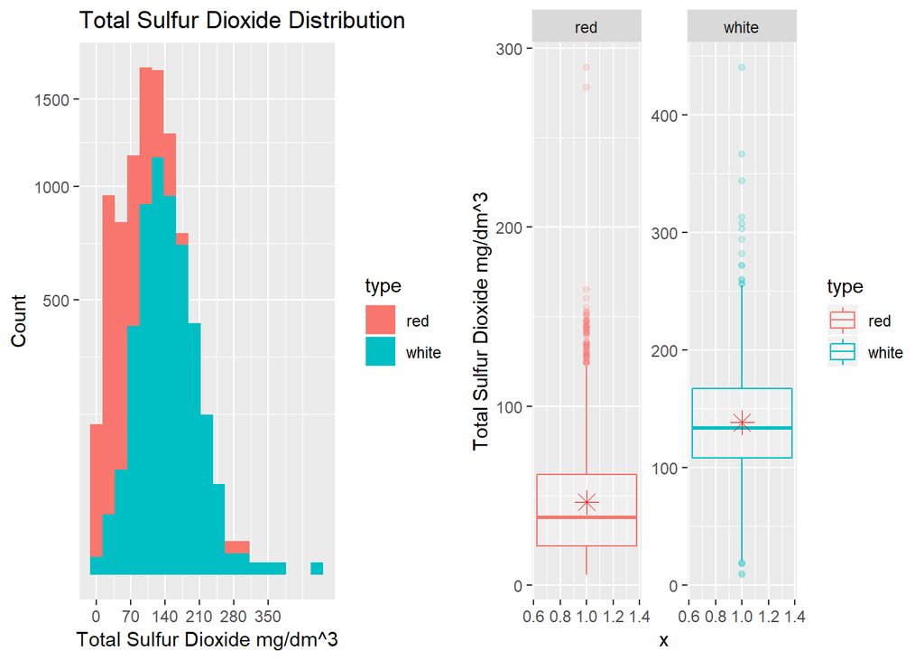

```
## # A tibble: 2 x 4
##   type   mean median     n
##   <chr> <dbl>  <dbl> <int>
## 1 red    46.5     38  1599
## 2 white 138.     134  4898
```

White wine also has a very high concentration of totla sulfur dioxide compared to the red wine. We could also see in the box plots that white wine has an outlier with total sulfur dioxide higher than 400 where as the outliers of red wine have total sulfur dioxide above 250.

## 1.8.1 Density:

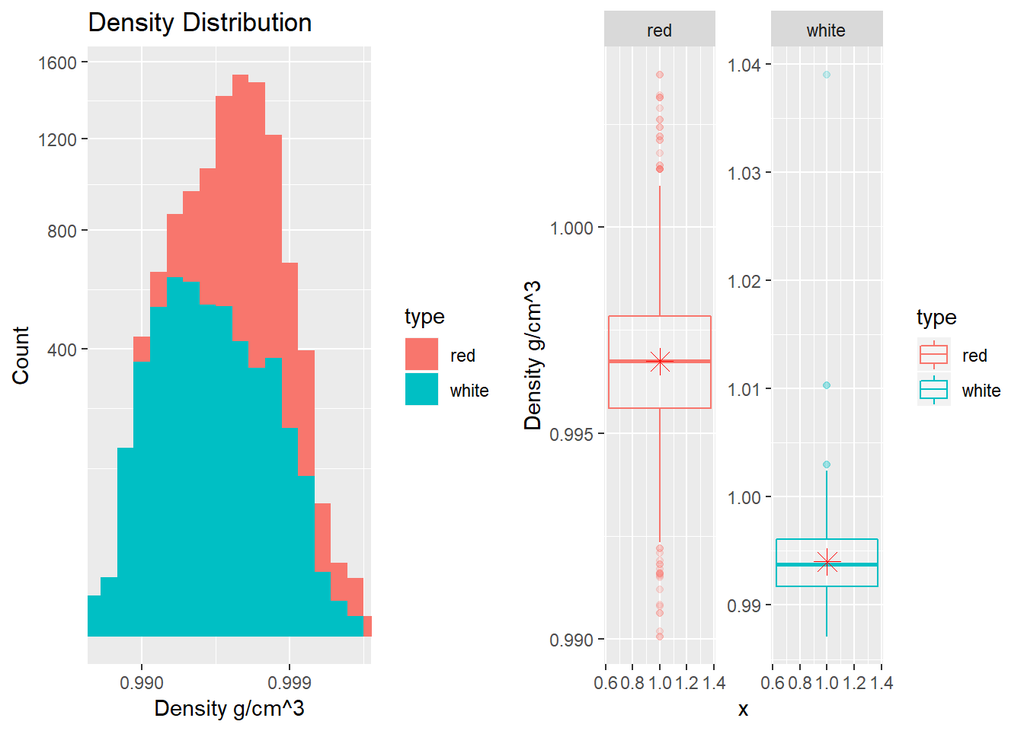

```
## # A tibble: 2 x 4
##   type   mean median     n
##   <chr> <dbl>  <dbl> <int>
## 1 red   0.997  0.997  1599
## 2 white 0.994  0.994  4898
```

## 1.9.1 pH:

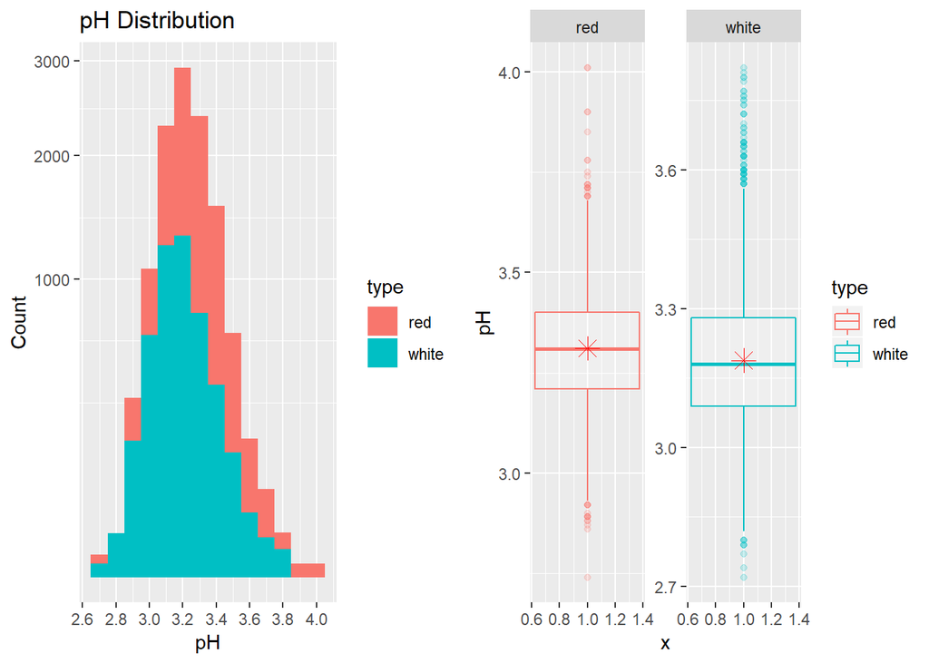

```
## # A tibble: 2 x 4
##   type   mean median     n
##   <chr> <dbl>  <dbl> <int>
## 1 red    3.31   3.31  1599
## 2 white  3.19   3.18  4898
```

## 1.10.1 sulphates:

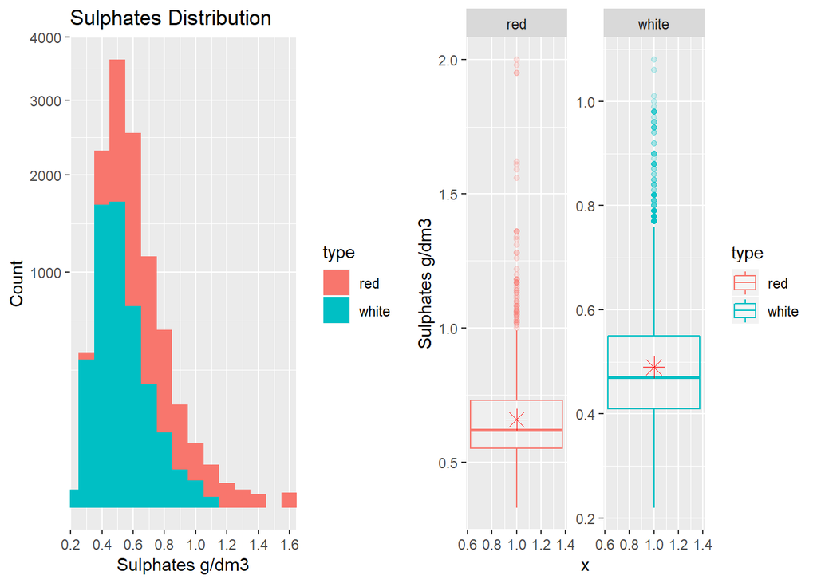

```
## # A tibble: 2 x 4
##   type   mean median     n
##   <chr> <dbl>  <dbl> <int>
## 1 red   0.658   0.62  1599
## 2 white 0.490   0.47  4898
```

1.10.2 red wine has a higer sulphates amount than the white wine. Red wine has some outliers with sulphates more than 1.2 grams. Red wine appears to some outliers with sulphates of up to 2.00 g/dm3.

## 1.11.1 Alcohol:

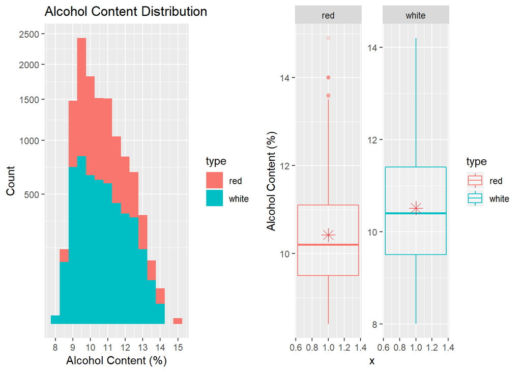

```
## # A tibble: 2 x 4
##   type   mean median     n
##   <chr> <dbl>  <dbl> <int>
## 1 red    10.4   10.2  1599
## 2 white  10.5   10.4  4898
```

1.11.2 Both wine types have very similar alcohol percentage by volume, however white wines have a higher alcohol concentration. The above plot also shows that both wines peak at 9.5 % alcohol. Red wines have some outliers with alcohol contents higher than 14%.

## 1.12.1 Quality:

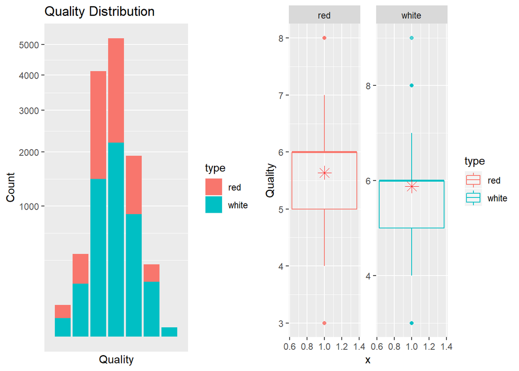

# Univariate Analysis

### What is the structure of your dataset?

The datasets that I chose for this analysis are very tidy and do not need a lot of wrangling. I had to combine both into one data set as “wine”, since both datasets had the same variables. The combined dataset had a total of 6497 observations and 14 variables.

Of the 14 variables, the first one is just the row number and the last variable indicates whether a particular observation is for red or white wine.

### What is/are the main feature(s) of interest in your dataset?

I am intersted to find if there are certain chemicals that affect the quality of wine. Furthuremore, I want to know if there is a significant difference between the contents of red wine and white wine. If there is a difference, what are those and are those differnece contributing significantlly to the quality of the wine.

In addition, I want to see if there is a significant correlation between certian components of wine. I am mainly interested to see the correlcation between chloride and residual sugar, alcohol and residual sugar, sulphates and residual sugar

### What other features in the dataset do you think will help support your investigation into your feature(s) of interest?

It will be helpful to look into sugar residual, chlorides, pH , alcohol volume, density and quality of each wine.

### Did you create any new variables from existing variables in the dataset?

I created one variable “type” to specify whether a wine is red or white. It was necessary for analysis of both types at once.

### Of the features you investigated, were there any unusual distributions? Did you perform any operations on the data to tidy, adjust, or change the form of the data? If so, why did you do this?

I noticed that some there are some wines with abnormal residual sugar, free sulfur dioxide, volatile acidity, and citric acid.

# 2. Bivariate Plots Section

First I would like to plot a ggpairs plot of the only 1000 random sample of the wine against each other to see the relationship among the variables.

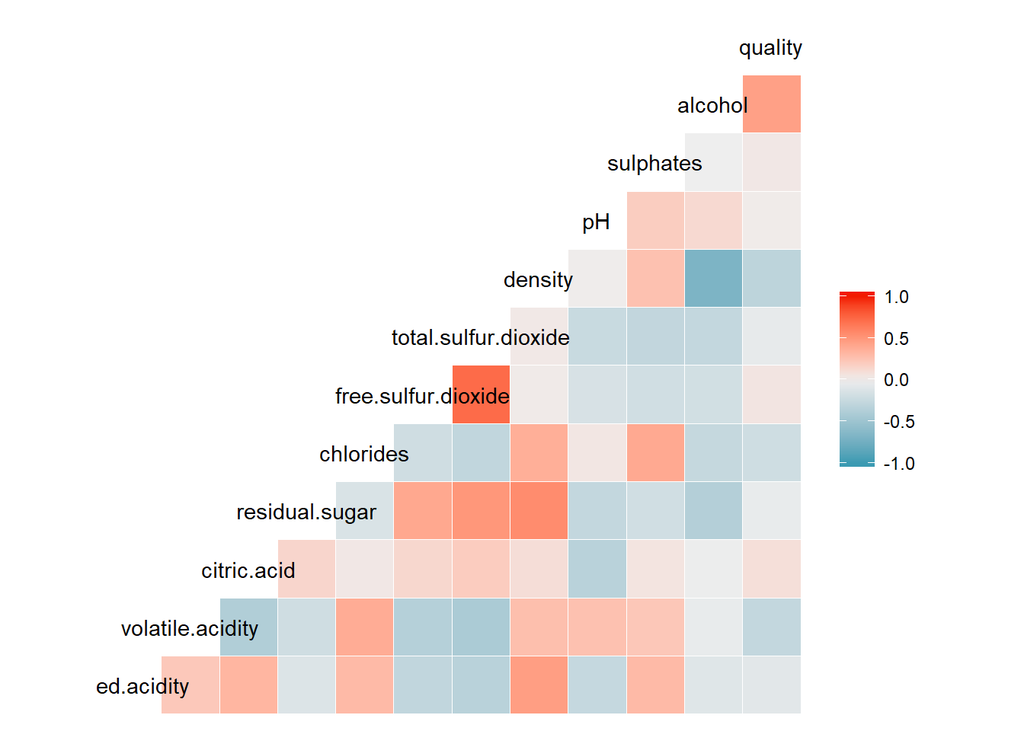

Next, lets look at the correlation of the variables and see how correlated our variables are the wine quality:

```
##                             [,1]
## fixed.acidity        -0.07674321
## volatile.acidity     -0.26569948
## citric.acid           0.08553172
## residual.sugar       -0.03698048
## chlorides            -0.20066550
## free.sulfur.dioxide   0.05546306
## total.sulfur.dioxide -0.04138545
## density              -0.30585791
## pH                    0.01950570
## sulphates             0.03848545
## alcohol               0.44431852
```

Alcohol, density, chlorides and volatile acidity are correlated with wine quality. In the following section, we will explore these correlations in more details.

## 2.1.1 Alcohol Vs. Quality

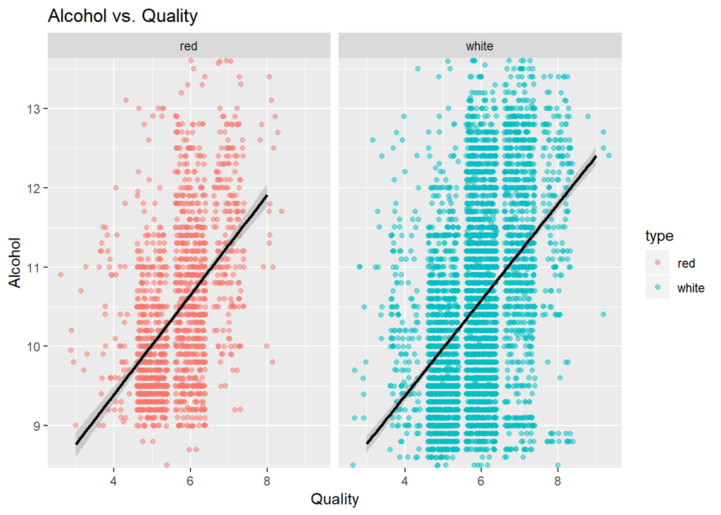

```
## [1] 0.4761663
```

```
## [1] 0.4355747
```

## 2.2.1 Density vs. Quality

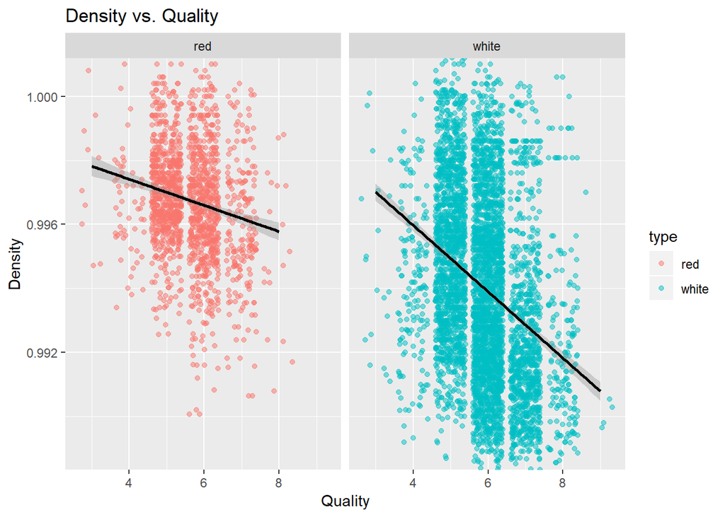

```
## [1] -0.1749192
```

```
## [1] -0.3071233
```

The above plot shows that ther is a negative correlation between density and wine quality.. As the water density increases, the wine quality decreases. Again, it looks like the the correlation is stronger for white wines compared to red wines. White wine has a stronger correlation with quality than the red wine.

## 2.3.1 Chlorides vs. Quality

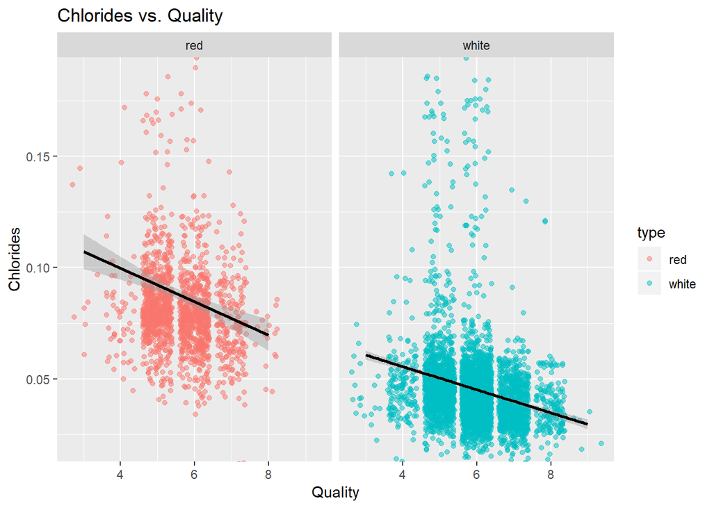

```
## [1] -0.1289066
```

```
## [1] -0.2099344
```

The above plot shows that there is negative and weak correlation between the chlorides and the wine qaulity. We could see thta in both wine types, the chlorides levels are highest in wines in the 5-6 quality categories. White wine has somewhat stronger correlation with quality than the red wine.

## 2.4.1 volatile acidity vs. Quality

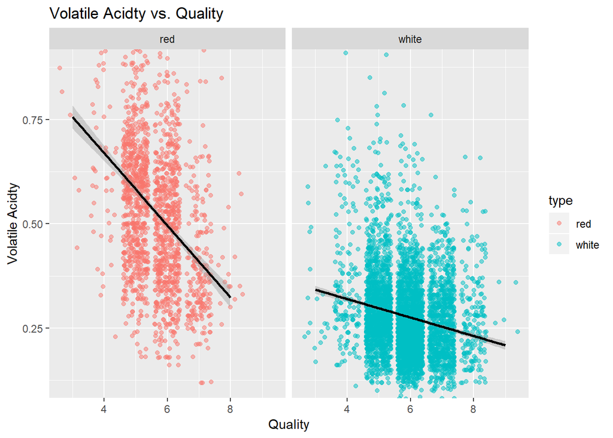

```
## [1] -0.3905578
```

```
## [1] -0.194723
```

The above plot shows that there is a strong negative correlation between the volatile acidity of red wine and it’s quality, however, the correlation of volatile and white wine is somehow weak. We could also see that volatile acidity of red wines has stronger correlation with quality than the white wine’s.

## 2.5.1 pH vs. Quality

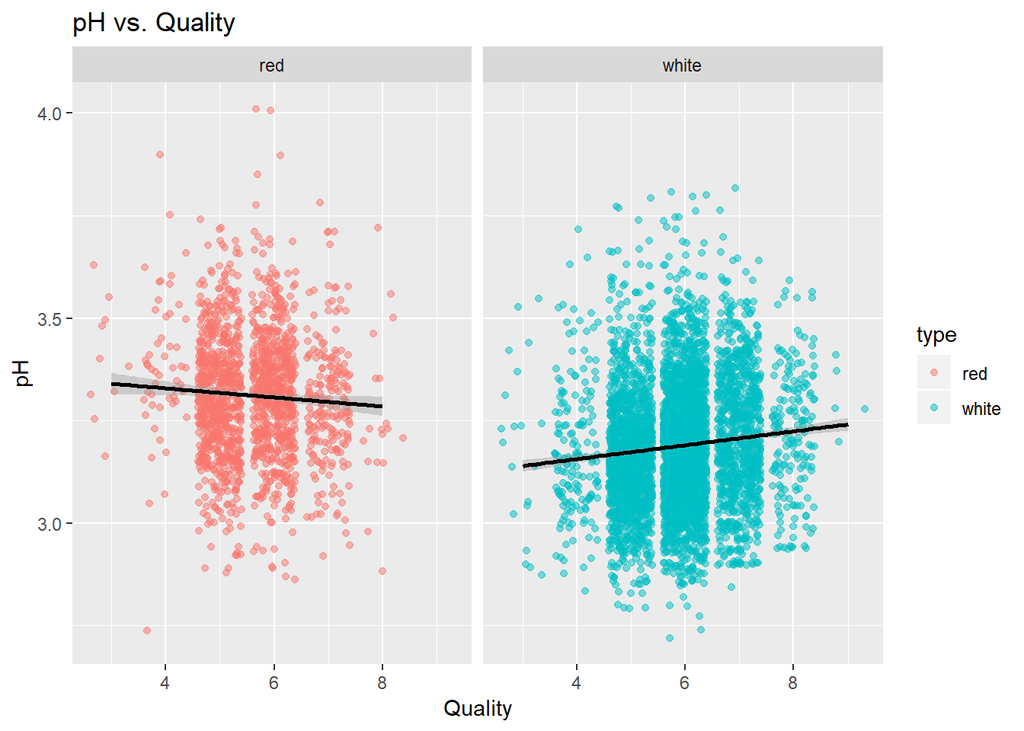

```
## [1] -0.05773139
```

```
## [1] 0.09942725
```

The above plots shows two different correlation for each wine type. White wines seem to have a positive correlation between pH levels and wine quality, however, red wines have a negative correlation between wine pH level and wine quality.

# Bivariate Analysis

### Did you observe any interesting relationships between the other features (not the main feature(s) of interest)?

The most interesting relationship was between the pH and wine quality. There seems to be a big difference between red and white wine. Red wines display a negative corelation between pH and wine quality, while white wines display a stronger positive correlation between pH and wine quality.

### What was the strongest relationship you found?

The strongest relationship was was between alchol content and wine quailty for both red and white wines. There was also a strong relationship between the volatile acidity and wine quality of the red wine.

# 3. Multivariate Plots Section

In this section, we will be looking into the relationship of multiple variables of the wine dataset. In particular, we will be analysing alcohol vs. density, alcohol vs residual sugar, and pH vs chlorides.

## 3.1.1 Alcohol and Density relationship colored by Quality:

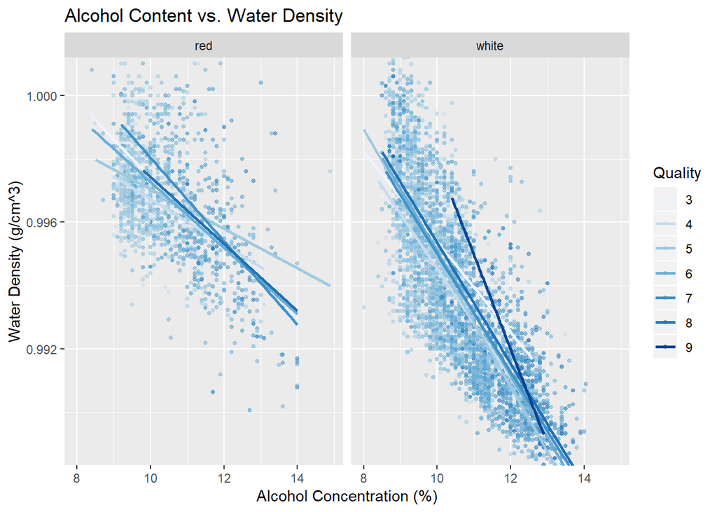

There is an obvious decrease in water density as the alcohol increases across all wine qualities

## 3.2.1 Residual Sugar Vs Alcohol Content Colored by Quantity:

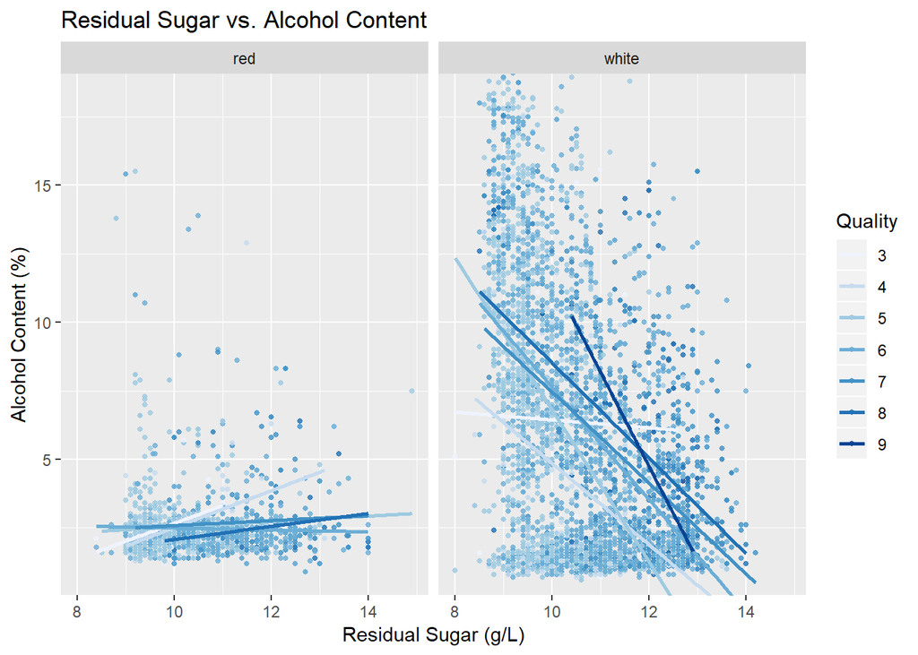

# Multivariate Analysis

### Talk about some of the relationships you observed in this part of the investigation. Were there features that strengthened each other in terms of looking at your feature(s) of interest?

For all wine quality in both red and white wines, the relationship between water density and alcohol content is strong. As the water density increases, the alcohol content decreass. There was only a few outliers to this, but we could ignore those given the size of the dataset.

### Were there any interesting or surprising interactions between features?

One interesting obervations that I could see what between the alcohol content and residual sugar level for white wines. The relationship is very strong, as the alcohol content increases, the sugar level decreases in white wines. However, red wine seems to be constant throught this change.

# Final Plots and Summary

### Plot One: Alcohol content vs. wine quality

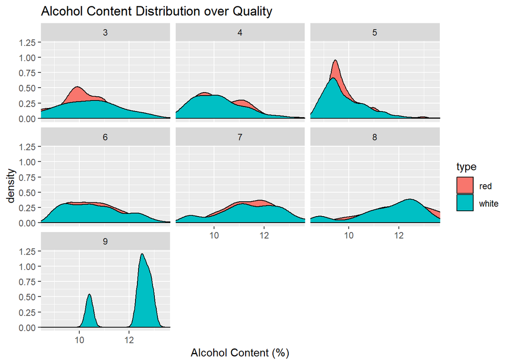

### Description One

The alcohol content of both types of wine seems to have very similar distribution across most of the quality levels. However, white seems to have more samples with higher alcohol contents in and higher quality of up to 9.

### Plot Two : pH vs. wine Quality

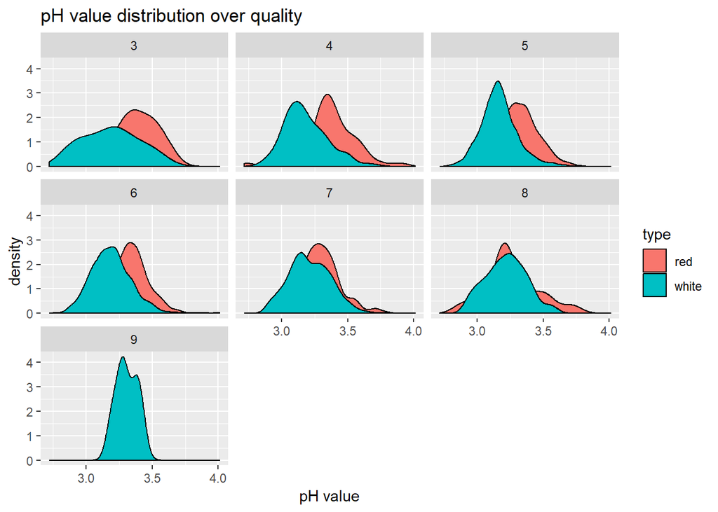

### Description Two

The plot above shows that red wine has higher levles of pH up to wines with a quality of 7. White wine seems to have higher pH content in wines with a quality of higher than 7. We could also see that the values are more spread for quality levels of up to 8, however, the pH value is more narrow for wines with the quality of 9.

### Plot Three : Sugar vs. wine Quality

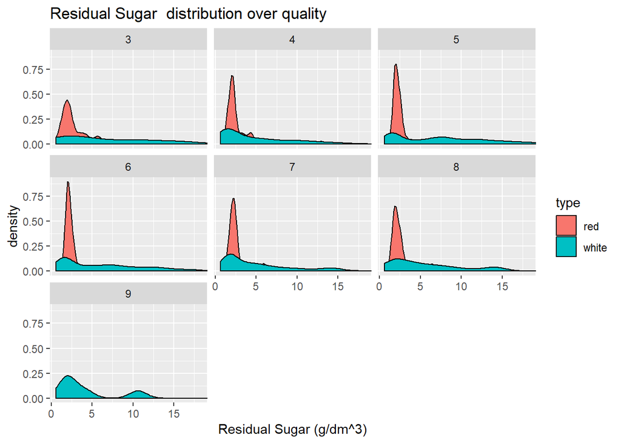

# Reflection

Before starting this project, I had now idea of the components of either types of wine. After reading and analysing these datasets, I learned alot about the type of wine and what are the important factors in determing the quality of wine. I was expecting that red and white wines might have different alcohol contents. However, after the analysis I found that both wine types have very similar distribution of alcohol content.

I thought it would be fun to analyze two dataset at once. However, there during the process I faced challenges in performing explantory analysis on the entire dataset at once. I had to search more and read more in order to be able to perform the analysis.

## Insights for future work:

I think it will be important to have equal number of observations in order to draw solid conclusion between the component difference of red and white wines.

## Reference:

P. Cortez, A. Cerdeira, F. Almeida, T. Matos and J. Reis. Modeling wine preferences by data mining from physicochemical properties. In Decision Support Systems, Elsevier, 47(4):547-553. ISSN: 0167-9236.